# Programming Assignment 2

Joseph Walker - jpwalker625@gmail.com

March 7, 2017

```r
knitr::opts_chunk$set(echo = FALSE, warning = FALSE, message = FALSE)
```

### Problem 1

Read in the Mixpanel Web Analytics json files and tidy them.

- events: *“berkeley_event-export.json”*
- people: *“berkeley_people-export.txt”* (I converted the json file into a text file in order to read it in.)

Join the two data sets together on the `distinct_id` variable into a third data set.

Clean up the column names of `events_people` with a function that converts a string to snake case.

Replace NA’s for `artist` and `page_name` with ‘None’ and ‘No Page Name’, respectively.

Plot the number of page views grouped by page_name & artist.

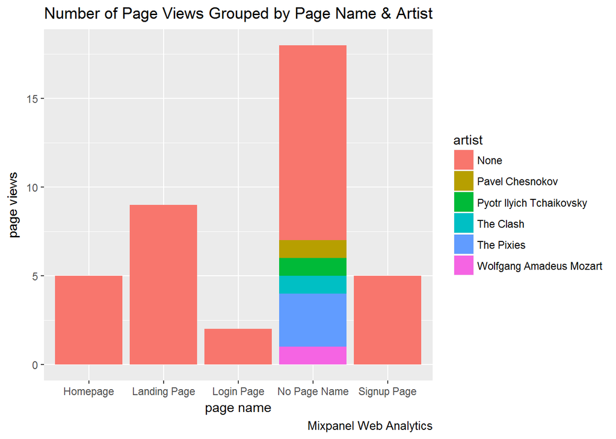

### Problem 2

Read in the AOL search data and fix the column names with the snake case function.

Sessionize the search records.

- A user session is all events for a given user where there is no more than 30 minutes between events.

Generate the following session statistics:

- anon_id
- session_sequence_number
- session_id
- number_searches
- session_started_at
- session_length
- number_clicks
- mean_item_rank
- mean_number_search_terms

Plot the statistics by session:

1. The distribution of session durations (histogram count)

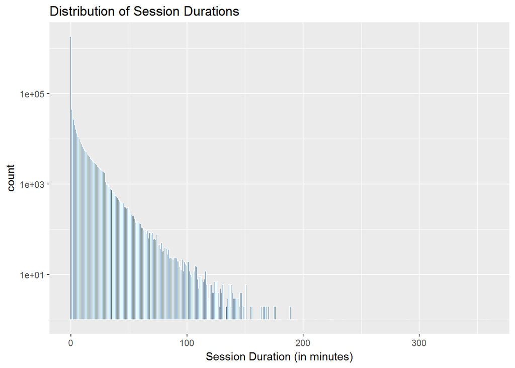

2. The distribution of the number of clicks per session (histogram count)

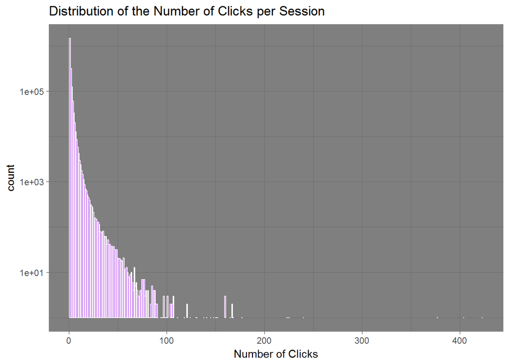

Summarise the data to the user level:

Plot statistics by user:

3. The distribution of the number of sessions by user (histogram count)

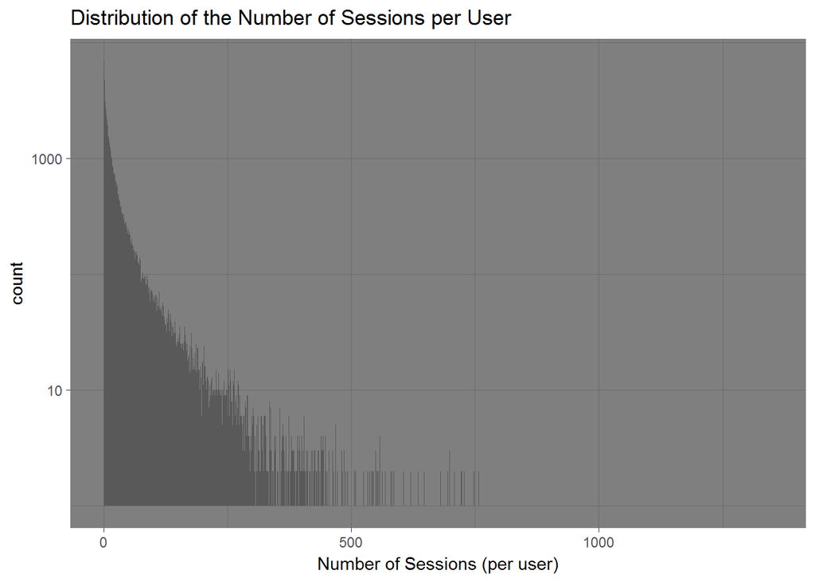

4. The distribution of mean session duration by user (histogram count)

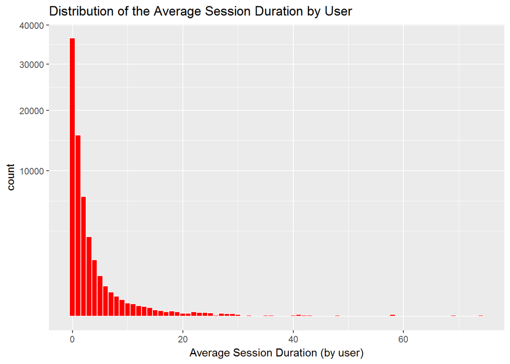